# Literature review of disfluency: Research trend

In this exercise, I explored research trends in the study of disfluency. My personal research focuses on speech disfluency (e.g., fillers, pauses, repetitions, false starts), which has long been evaluated negatively, despite its frequent occurrence in everyday speech, including in the speech of typical, healthy individuals. A possible reason for this persistent negative evaluation is that people often (mistakenly) associate disfluency, a natural language feature for everyone, with stuttering, which is a language disorder. In this exercise, I analyzed how much disfluency research has been dedicated to the clinical population, which in turn highlighted the amount of research directed at typical disfluency over the years.

## Methods

I downloaded two data sets from Scopus using the following search keywords: (1) disfluency AND {speech OR language OR linguistic} (2) disfluency AND {speech OR language OR linguistic} AND {stuttering OR patient OR pathology} The first data set included a list of past research related to speech disfluency, while the second data set included that specifically on stuttering.

```python
# Import libraries
import pandas as pd
import matplotlib.pyplot as plt
import seaborn as sns
```

```python
# Read two excel files into pandas dataframes
all = pd.read_excel('C:/Users/jonat/OneDrive - PennO365/Jonathan (UPenn)/Year 3 courses/EDUC 5913 Programming fundamentals of Python/Week10/disfluency_all.xlsx')
stuttering = pd.read_excel('C:/Users/jonat/OneDrive - PennO365/Jonathan (UPenn)/Year 3 courses/EDUC 5913 Programming fundamentals of Python/Week10/disfluency_stuttering.xlsx')
```

```python
# Create a dictionary to store dataframes
files = {
    'all': all,
    'stuttering': stuttering,
}
```

## Procedure

I counted the number of publications in each year in the two datasets. This data would enable me to understand how the research trend was over the years.

```python
# Create an empty dataframe to do the counts
year_counts = pd.DataFrame()
```

```python
# Count occurrences of each year in the "Year" column for each file
for file_name, df in files.items():
    year_count = df['Year'].value_counts().reset_index() #selects the column "Year", count the no. of occurences in years, and convert it into a dataframe
    year_count.columns = ['Year', 'Count'] # Renaming
    year_count['File'] = file_name  # Add the file name as a new column
    year_counts = pd.concat([year_counts, year_count], ignore_index=True) # Concatenate the existing year_counts with the new year_count dataframe
```

## Results

I plotted the bar charts of my data to see the trends.

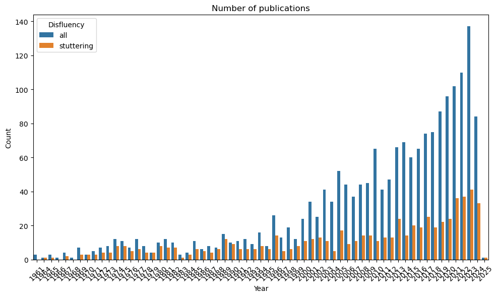

```python
# Plot the data
plt.figure(figsize=(10, 6))
sns.barplot(x='Year', y='Count', hue='File', data=year_counts)

# Customize the plot
plt.title('Number of publications')
plt.xlabel('Year')
plt.ylabel('Count')
plt.legend(title='Disfluency', loc='upper left')
plt.xticks(rotation=45)
plt.tight_layout()

# Show the plot
plt.show()
```

## Discussion

As shown in the figure, both the trends for disfluency (blue bars) and stuttering-specific disfluency (orange bars) increased over the years. However, the magnitude of increase was much larger for disfluency than for stuttering-specific disfluency since the 2000s. Additionally, the bar heights were very similar in the early research before 1995. These contrasts suggest that a significant portion of early disfluency research focused on the clinical population. While publications in this area continued to grow in later years, most recent research shifted toward non-stuttering-specific disfluency, which might include typical disfluency or other types not specified in the data sets of this exercise.